# Predicting Survival Probability of NASA Aircraft Engines

Using Cox Proportional Hazards Model

Jayme Reed & Brad Paton (Advisor: Dr. Cohen)

April 13, 2025

## Cox Proportional Hazards (CPH) Model

What is it?

- A statistical regression method specializing in modeling time-to-event predictions with survival data (Abeysekera and Sooriyarachchi 2009)
  - Survival data has a value for time and an indicator column for an event
- Is a method that can deal with censored data
  - Censored data is when the information about an individual in a study is only known for a certain period of time (Klein and Moeschberger 2005)
- Primarily used in the health field but has applications in predicting bank failure, the survival probability of machines, and insurance likelihood payouts

## Limitations

- The model assumes that as time goes on, the survival probability will approach zero with no survivors (Asghar, Khalil, and Uddin 2024)
- The proportional hazards assumption can limit the ability to correctly predict the effect of a variable (Jiang, Wu, and Li 2024)
- The covariate selection can become biased and may not accurately represent the true data (Wang, Chang, and Lin 2025),(Zhang, Cheng, and Carrillo-Larco 2025)
- The model cannot provide a specific value for when the event will happen, only the probability of when the event might happen

## Mathematical Formulas

- Survival Function:

  $S(x) = \int_{x}^{\infty} f(x)dx$
- Hazard Function:

  $h(x) = \lim\limits_{\Delta x \rightarrow 0} \frac{P[x \leq X < x + \Delta x|X \geq x]}{\Delta x}$
- CPH Model Hazard Function:

  $h(t|\mathbf Z) = h_0(t)\text{exp}(\sum\limits_{k=1}^{p} \beta_kZ_k)$
- Proportional Hazards Ratio:

  $\frac{h(t|\mathbf Z)}{h(t|\mathbf Z*)} = \text{exp}[\sum\limits_{k=1}^{p} \beta_k(Z_k - Z_k^*)]$
- Cumulative Hazard Function:

  $H(x) = \int_0^x h(u) du$

## Assumptions

There are four assumptions for CPH:

- Independence assumption
  - Assumes that the survival times of observed subjects are independent of each other (Nahhas 2025)
- Non-informative Censoring Assumption
  - Assumes that censoring is non-informative (Nahhas 2025)

## Assumptions, Cont.

- Linearity Assumption
  - Assumes the relationship between covariates and the outcome is a linear relationship
  - This is tested using the Martingale residuals for each covariate with the equation Martingale Residuals = Observed Events - Expected Results (Nahhas 2025)
    - The residuals are examined visually
    - If linear and appear to have a slop of zero, the assumption is not violated (Amini 2015)

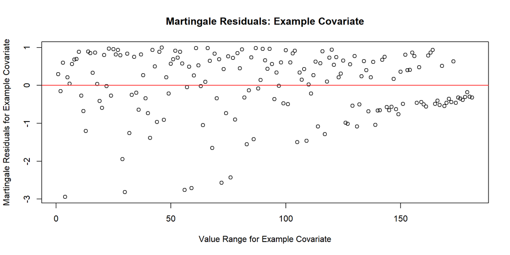

## Assumptions, Cont.

  Example of Schoenfeld plot and results

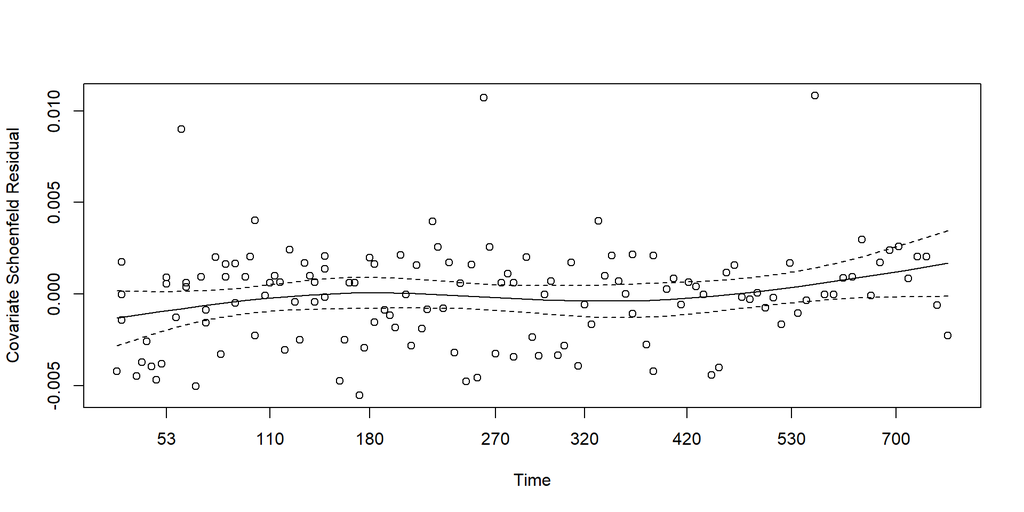

  | variable | chisq | df | p |
  | --- | --- | --- | --- |
  | meal.cal | 4.0478025 | 1 | 0.0442289 |
  | age | 0.4838469 | 1 | 0.4866850 |
  | GLOBAL | 4.1100198 | 2 | 0.1280916 |

## Conclusion

## References

Abeysekera, W. W. M., and M. R. Sooriyarachchi. 2009. “Use of Schoenfeld’s Global Test to Test the Proportional Hazards Assumption in the Ox Proportional Hazards Model: An Application to a Clinical Study.” https://www.researchgate.net/publication/238483310_Use_of_Schoenfeld's_global_test_to_test_the_proportional_hazards_assumption_in_the_Cox_proportional_hazards_model_An_application_to_a_clinical_study.

Amini, Zaki. 2015. “Log-Linearity for Cox’s Regression Model.” https://www.duo.uio.no/bitstream/handle/10852/45377/thesis_zaki.pdf?sequence=15&isAllowed=y.

Asghar, Naseem, Khalil Umair, and Iftikhar Uddin. 2024. “Mixture and Non-Mixture Cure Models for the Survival Analysis of SARS-CoV-2 Patients in Khyber Pakhtunkhwa, Pakistan.” *Pakistan Journal of Medical Sciences* 40 (8): 1841–46.

Bustan, M. Nadjib. 2018. “Cox Proportional Hazard Survival Analysis to Inpatient Breast Cancer Cases.”

Jiang, Nan, Wu Yongfa, and Chengjia Li. 2024. “Limitations of Using COX Proportional Hazards Model in Cardiovascular Research.” *Cardiovascular Diabetology*, no. 1: 1–2.

Klein, John P., and Melvin L. Moeschberger. 2005. *Survival Analysis: Techniques for Censored and Truncated Data*. 2nd ed. Springer.

Nahhas, Ramzi W. 2025. *Introduction to Regression Methods for Public Health Using r*. 1st ed. Chapman & Hall.

Wang, Weiwei, Xiaotian Chang, and Feifei Lin. 2025. “Adding Salt to Foods and Risk of Incident Depression and Anxiety.” *BMC Medicine*, no. 1: 1–10.

Zhang, Yue, Yangyang Cheng, and Rodrigo M Carrillo-Larco. 2025. “Postpartum Depression in Relation to Chronic Diseases and Multimorbidity in Women’s Mid-Late Life: A Prospective Cohort Study of UK Biobank.” *BMC Medicine* 23 (1): 1–13.